# 343.01: Class Markdown Key

Oropendola

2024-08-20

## 1: RMarkdown and R Code

In an RMarkdown Document, you can write in prose, as you would in any text editor. When you hit the “Knit” button, it will generate an easy-to-read html, pdf, or docx file. We will use these to integrate note-taking, class code, and assignments throughout the semester.

When editing text, we’ll start with the basics: *italics* are triggered with one set of asterisks, and **bold** with two sets. For simplicity’s sake, we will **not** indent paragraphs, and instead use double line breaks.

When we want to run code in R, we need to start an “R Chunk”, we will set them up like the text below. In today’s class, we will have `echo = TRUE` or `= T`, so that we can see the code in the html output.

```r
# Our first code
103+577
```

```
## [1] 680
```

At its most basic, R is a fancy calculator, capable of performing math quickly and reproducibly. We will often use annotations (which always start with a ‘#’) to help us remember what a bit of code does, or to flag something to come back to later

```r
# Do spaces matter?
103+577
```

```
## [1] 680
```

```r
# multiplication
77*23
```

```
## [1] 1771
```

```r
# division
99/33
```

```
## [1] 3
```

```r
# parentheses to protect order of operations
(8-3)*(4+7)
```

```
## [1] 55
```

```r
# exponents
11^2
```

```
## [1] 121
```

R is object-oriented, which means it is structured around data objects that have names, to which we perform functions or from which we make new products, like plots!

An example of a named data object is a vector: a series of values with a name. We can create and ask questions above related vectors. In R, we start with a name and then use “<-” to indicate what is in that name.

```r
# high temps from four days
tmax <- c(78,77,80,83) # c() strings values together
# low temps from four days
tmin <- c(62,55,56,59)
# preview the data in the console by running the name
tmax
```

```
## [1] 78 77 80 83
```

```r
tmin
```

```
## [1] 62 55 56 59
```

```r
# check to see if an object is a vector
is.vector(tmax)
```

```
## [1] TRUE
```

```r
# create a new vector of temperature changes
tchange <- tmax - tmin
# preview the new vector in the console
tchange
```

```
## [1] 16 22 24 24
```

## 2: data.frames, functions, and arguments

Data.frames are a common table structure used in R. Each row is an observation, each column is a variable. Each column should have the same data type: there should only be numeric data in a temperature column, only categorical or factor data in a “species” column, etc.

We will usually create data.frames by assigning a name, and then importing data from csv files using the **function** `read.csv()`. A **function** is a pre-coded program that performs an operation. We specify how that function works by adding **arguments**.

For example, R does not always know to treat text from a csv file as factors. On most operating systems, `read.csv()` will leave text as character or strings, and not sort a column into category levels.

```r
# read in the weather data without arguments
# my.name <- function("filename.csv")
weather <- read.csv("data_week_01.csv")
# use the function "summary()" to find out what is in the data.frame
summary(weather)
```

```
##   station_id        station_location       date                prcp
##  Length:8773        Length:8773        Length:8773        Min.   :0.0000
##  Class :character   Class :character   Class :character   1st Qu.:0.0000
##  Mode  :character   Mode  :character   Mode  :character   Median :0.0000
##                                                           Mean   :0.1115
##                                                           3rd Qu.:0.0500
##                                                           Max.   :5.5800
##       tmax            tmin         wind_degrees   wind_speed
##  Min.   : -6.0   Min.   :-21.00   Min.   : 10   Min.   : 0.450
##  1st Qu.: 49.0   1st Qu.: 31.00   1st Qu.:140   1st Qu.: 6.710
##  Median : 67.0   Median : 45.00   Median :220   Median : 8.500
##  Mean   : 64.4   Mean   : 44.47   Mean   :209   Mean   : 8.969
##  3rd Qu.: 81.0   3rd Qu.: 60.00   3rd Qu.:300   3rd Qu.:10.960
##  Max.   :104.0   Max.   : 79.00   Max.   :360   Max.   :28.630
##  wind_cardinal
##  Length:8773
##  Class :character
##  Mode  :character
##
##
##
```

You can see that R is smart enough to identify numbers, and summarizes them with ranges and averages. It will notes missing values as `NA` without issue.

However, it is “blind” to the **character** values in station_id, location, and date. It considers each one as a unique STRING of text.

Let’s modify our `read.csv()` function with an **argument** called `stringsAsFactors` to correct this.

```r
# start the code the same way
weather <- read.csv("data_week_01.csv",
                    stringsAsFactors = TRUE)
# use the function "summary()" to see if it worked!
summary(weather)
```

```
##        station_id             station_location         date
##  USW00013740:4211   Richmond Airport  :4211    1984-03-20:   2
##  USW00014848:4562   South Bend Airport:4562    1984-03-21:   2
##                                                1984-03-22:   2
##                                                1984-03-23:   2
##                                                1984-03-24:   2
##                                                1984-03-25:   2
##                                                (Other)   :8761
##       prcp             tmax            tmin         wind_degrees
##  Min.   :0.0000   Min.   : -6.0   Min.   :-21.00   Min.   : 10
##  1st Qu.:0.0000   1st Qu.: 49.0   1st Qu.: 31.00   1st Qu.:140
##  Median :0.0000   Median : 67.0   Median : 45.00   Median :220
##  Mean   :0.1115   Mean   : 64.4   Mean   : 44.47   Mean   :209
##  3rd Qu.:0.0500   3rd Qu.: 81.0   3rd Qu.: 60.00   3rd Qu.:300
##  Max.   :5.5800   Max.   :104.0   Max.   : 79.00   Max.   :360
##
##    wind_speed     wind_cardinal
##  Min.   : 0.450   E:1297
##  1st Qu.: 6.710   N:2347
##  Median : 8.500   S:2500
##  Mean   : 8.969   W:2629
##  3rd Qu.:10.960
##  Max.   :28.630
##
```

R now “knows” the names of different factors - like the letter for cardinal directions, or the name of the airport the measurement was taken from.

`summary()` is just one exploratory function. We can also use `str()` to find a more concise vertical summary, or `head()` to see the first few rows.

```r
str(weather)
```

```
## 'data.frame':    8773 obs. of  9 variables:
##  $ station_id      : Factor w/ 2 levels "USW00013740",..: 1 1 1 1 1 1 1 1 1 1 ...
##  $ station_location: Factor w/ 2 levels "Richmond Airport",..: 1 1 1 1 1 1 1 1 1 1 ...
##  $ date            : Factor w/ 4564 levels "1984-01-01","1984-01-02",..: 80 81 82 83 84 85 86 87 88 89 ...
##  $ prcp            : num  0 0.53 0 0 0 2.2 0.4 0 1.8 0.78 ...
##  $ tmax            : int  66 60 64 60 65 50 57 61 57 48 ...
##  $ tmin            : int  38 47 41 38 30 44 38 38 46 34 ...
##  $ wind_degrees    : int  150 210 230 250 180 350 340 100 20 300 ...
##  $ wind_speed      : num  8.95 16.11 14.09 11.41 5.82 ...
##  $ wind_cardinal   : Factor w/ 4 levels "E","N","S","W": 3 3 4 4 3 2 2 1 2 4 ...
```

## 3: Navigating data.frames with [,], $, and more functions

The BIGGEST benefit of R is reproducibility: anyone can use the same code on the same data to get the same results, with (usually) no fear of over-writing a dataset or having an invisible formula in a cell, like you do in Excel.

However, it isn’t as easy to *see* your data in R, especially for large datasets. As such, we need to be comfortable navigating our data.frames with syntax and functions. While we learn to do this, we will also discover that R is quite picky about cAse sENsitvity and sp3lling.

```r
# Open a tab with a (big) preview of the data.frame.
#View(weather) # this works, but we DON'T want it in the final markdown
#view(weather) # this does not work - command needs to be capital V
#View(Weather) # this does not work - data.frame starts with a lowercase w
```

We will often want to know things about specific columns, rows, or specific cells within a data.frame. If we know the “position” of something within our data.frame, we can use the `name[row#,column#]` to view or extract it.

```r
# how many rows?
nrow(weather)
```

```
## [1] 8773
```

```r
# how many columns?
ncol(weather)
```

```
## [1] 9
```

```r
# the first row of the data.frame
weather[1,]
```

```
##    station_id station_location       date prcp tmax tmin wind_degrees
## 1 USW00013740 Richmond Airport 1984-03-20    0   66   38          150
##   wind_speed wind_cardinal
## 1       8.95             S
```

```r
# the first row and the second column
weather[1,2]
```

```
## [1] Richmond Airport
## Levels: Richmond Airport South Bend Airport
```

```r
# The first three rows and the first three columns
weather[1:3,1:3]
```

```
##    station_id station_location       date
## 1 USW00013740 Richmond Airport 1984-03-20
## 2 USW00013740 Richmond Airport 1984-03-21
## 3 USW00013740 Richmond Airport 1984-03-22
```

```r
# The cell from th 80th row and the seventh column
weather[80,7]
```

```
## [1] 240
```

This is useful, but tedious. After all, these are not just floating values – these are variables! We’ll almost always be asking questions about the *columns* of our dataset, which we know have names.

```r
# get a list of column names
colnames(weather)
```

```
## [1] "station_id"       "station_location" "date"             "prcp"
## [5] "tmax"             "tmin"             "wind_degrees"     "wind_speed"
## [9] "wind_cardinal"
```

To make life easy for us, R will give us a drop-down menu of column names any time we type the data.frame’s name followed by a dollar sign - which means we can run mathematical and statistical **functions** on them!

```r
# get a summary of the location column
summary(weather$station_location)
```

```
##   Richmond Airport South Bend Airport
##               4211               4562
```

```r
# find the mean of the maximum temperature
mean(weather$tmax)
```

```
## [1] 64.40305
```

```r
# find the median of minimum temperature
median(weather$tmin)
```

```
## [1] 45
```

```r
# find the standard deviation of precipitation
sd(weather$prcp)
```

```
## [1] 0.3082147
```

```r
# find the range of wind speed
range(weather$wind_speed)
```

```
## [1]  0.45 28.63
```

## 4: Basic plots

R comes with a simple plotting package. When we use it, we will usually use `plot()` function to make xy scatterplots or boxplots, and `hist()` for histograms. The syntax among these plots is shared; the arguments specify what data.frame$columns go on which axis, and what the labels and main title should be.

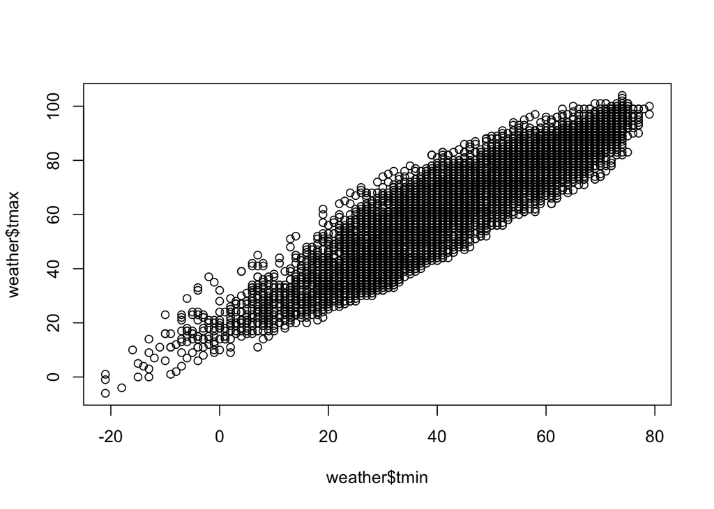

```r
# R's base plotting package
## You can make a lot of graphs by typing plot()
## plot(x = data.frame$column,
##      y = data.frame$column,
##      type = …,
##      labs = …)
# A: Ugly scatterplot
plot(x = weather$tmin,
     y = weather$tmax)
## simplified with defaults…
plot(weather$tmin,
     weather$tmax)
```

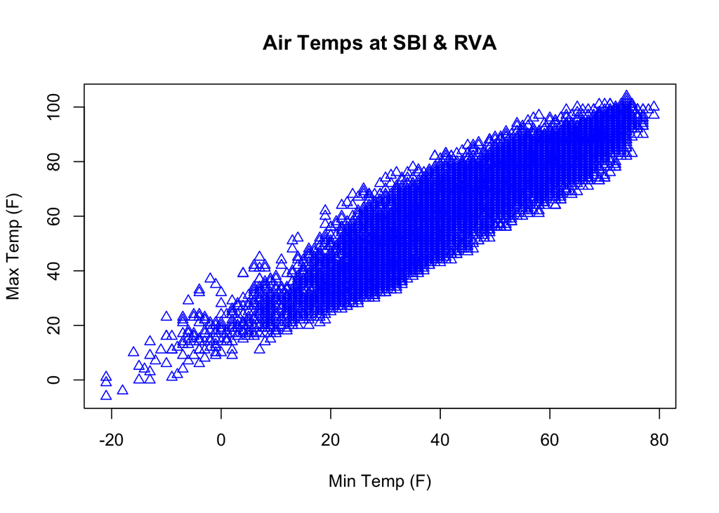

```r
# B: Prettier scatterplot:
plot(x = weather$tmin, #first default is x axis
     y = weather$tmax, # second default is y axis
     xlab = "Min Temp (F)", # x axis label
     ylab = "Max Temp (F)", # y axis label
     main = "Air Temps at SBI & RVA", # main title of graph
     col = "blue", #col changes colors
     pch = 2) #pch chances shape. 2 = triangle, 15 = solid squares
```

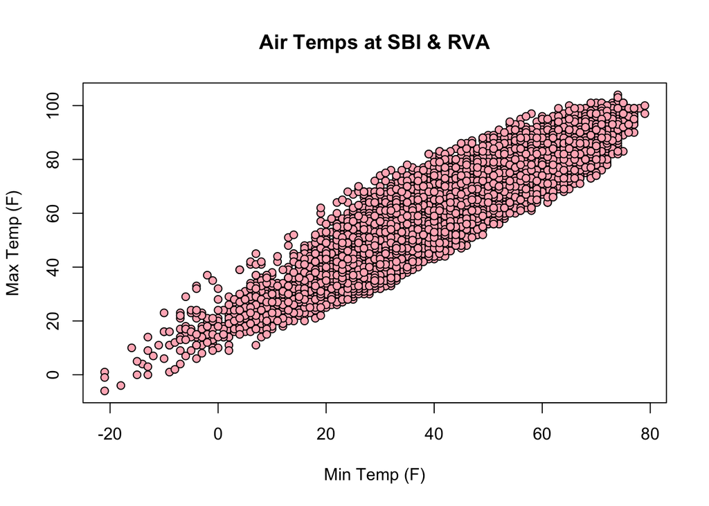

```r
plot(x=weather$tmin,
     y = weather$tmax,
     xlab = "Min Temp (F)",
     ylab = "Max Temp (F)",
     main = "Air Temps at SBI & RVA",
     pch = 21, #pch changes shape
     bg = "lightpink", #bg fill color
     col = "black", #col is border color
     cex = 1, #cex is point size
     lwd = 1) #lwd is width of border
```

```r
## simplified with defaults…
```

If one variable is categorical and the other is numeric, R should be smart enough to switch from a scatterplot to a boxplot.

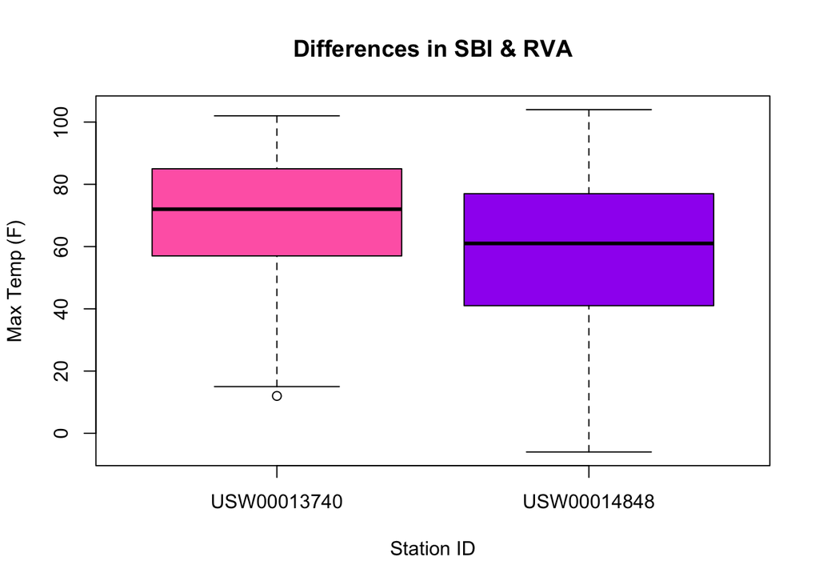

```r
## station_id is a categorical
plot(weather$station_id,
     y = weather$tmax,
     xlab = "Station ID",
     ylab = "Max Temp (F)",
     main = "Differences in SBI & RVA",
     col = c("hotpink", "purple")) #c(,) allows you to choose two different colors for each box
```

Sometimes, we just want to know the distribution of a single numeric variable. In these cases, histograms are our best friends! We only input the column of interest on the x-axis, because R will tabulate the frequency or number of observations on the y-axis for us.

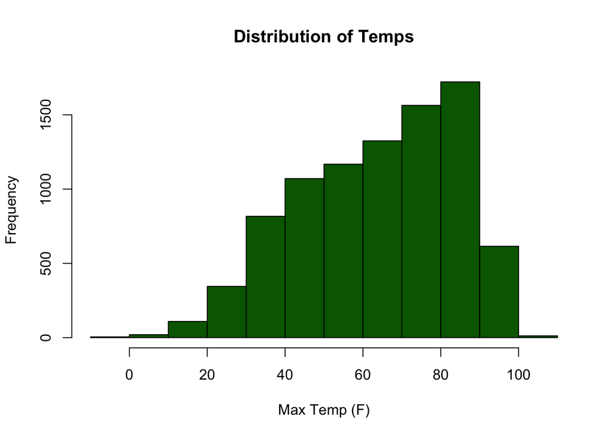

```r
hist(weather$tmax,
     xlab = "Max Temp (F)",
     main = "Distribution of Temps",
     col = "darkgreen")
```

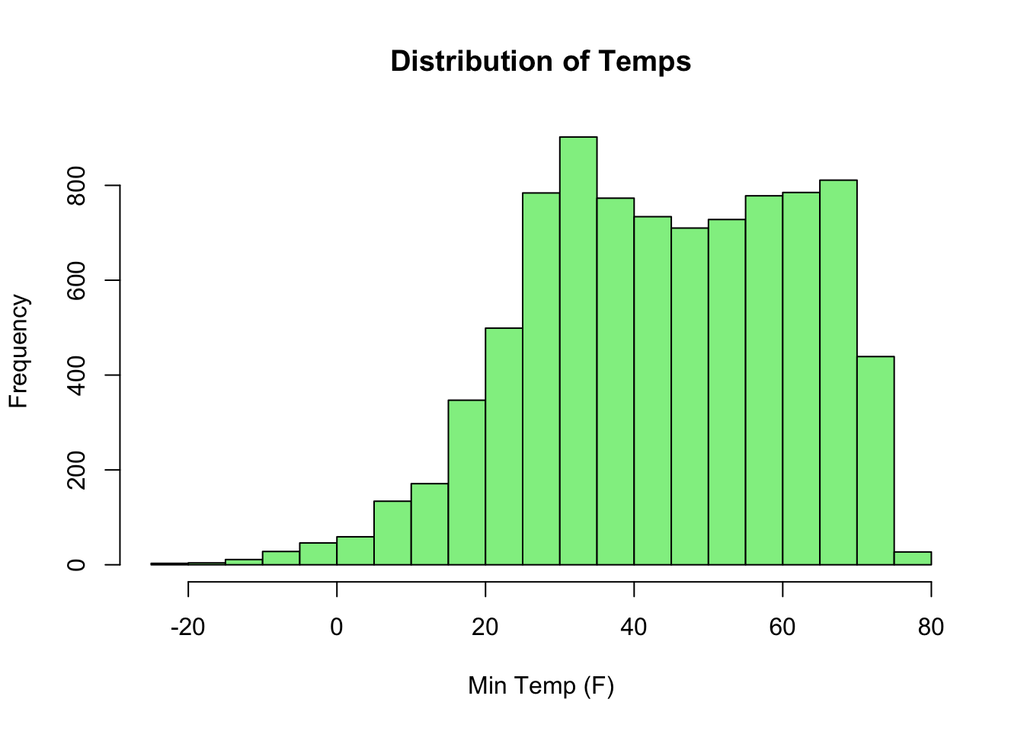

```r
hist(weather$tmin,
     xlab = "Min Temp (F)",
     main = "Distribution of Temps",
     col = "lightgreen")
```

## 5: Dealing with dates & times

Time data is incredibly annoying…humans write it differently depending on culture and context, leading to all manner of confusion during analysis. Computers prefer for dates to be read in as YYYY-MM-DD, but anyone who has ever opened Excel knows that such formatting goes out the window the instant a file is saved or updated.

Fortunately, there is a package in R called `lubridate` which specializes in wrangling date information into readable formats, and then extracting relevant parts of time data. To use it, we must first install it, and then require it into the R session.

```r
# bring the package in
require(lubridate)
```

Okay, here’s where object orientation really starts to matter: we need to **overwrite** the original `weather$date` column using the lubridate `ymd()` function to extract date information from the `$date` column.

```r
# what is the current data type of weather$date?
#summary(weather$date)
# overwrite it as a date using ymd()
weather$date <- ymd(weather$date)
# did it work?
summary(weather$date)
```

```
##         Min.      1st Qu.       Median         Mean      3rd Qu.         Max.
## "1984-01-01" "1987-02-10" "1990-02-12" "1990-02-13" "1993-02-12" "1996-06-30"
```

```r
str(weather$date) #compact summary
```

```
##  Date[1:8773], format: "1984-03-20" "1984-03-21" "1984-03-22" "1984-03-23" "1984-03-24" ...
```

We can use `lubridate` to create new columns that hold just a portion of the date column, such as the year or month. This is confusing in its own way, because sometimes the name of the column is the same as the name of the function.

```r
# make a year column
weather$Year <- year(weather$date)
# make a month column
weather$Month <- month(weather$date)
weather$ordDate <- yday(weather$date)
```

Time data is also annoying because in some cases, we should treat it as numeric, and other times we should treat it as a factor. For example, January is month number 1, February month 2, but they don’t make much sense when we consider the graphical relationship between month and minimum temperatures.

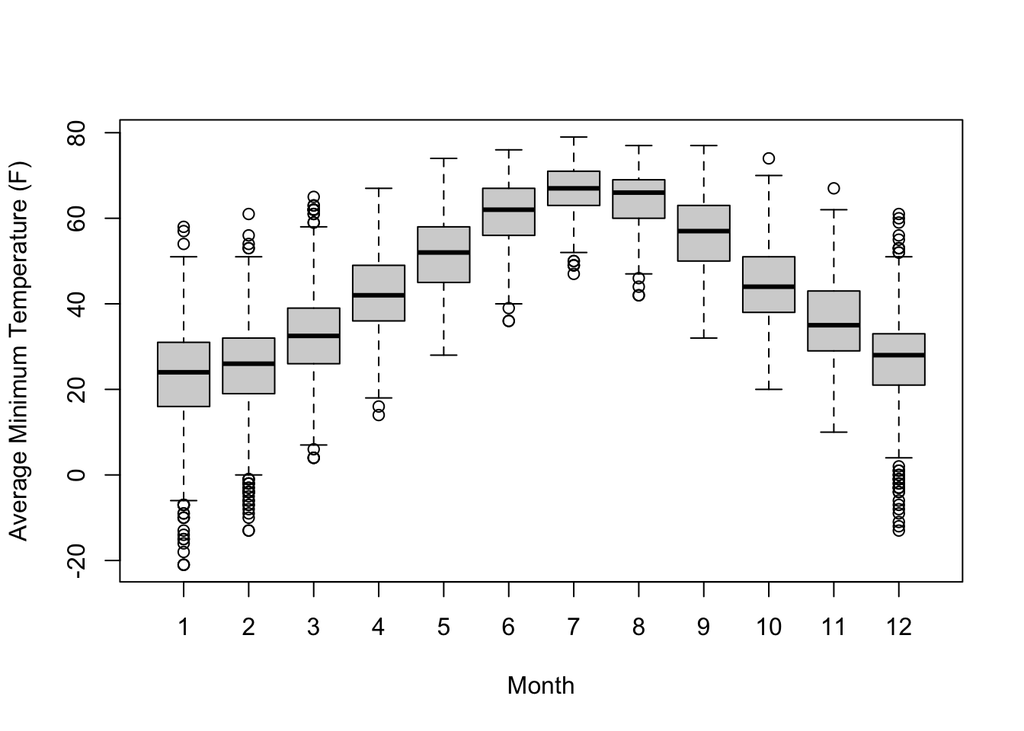

```r
# plot with month on x, tmin on y
plot(x = as.factor(weather$Month),# the extra circles in the plot are outliers
     y = weather$tmin,
     xlab = "Month",
     ylab = "Average Minimum Temperature (F)")
```

In this context, month makes far more sense as an ordinal category. Fortunately, we can use the `as.X()` family of functions to re-assign the data.type on the fly.

```r
# summary of month as is

# summary of a factor version of month

# replot with factor version of month
```

[output not shown]

[output not shown]

## 6: Nice graphs with ggplot2

R’s base plots are fine, but professional plots are often made with the R package `ggplot2`. Like lubridate, it needs to be installed and then required for it to work in an R session.

```r
require(ggplot2) #or tidyverse
```

After that, we have to get familiar with the ggplot syntax…

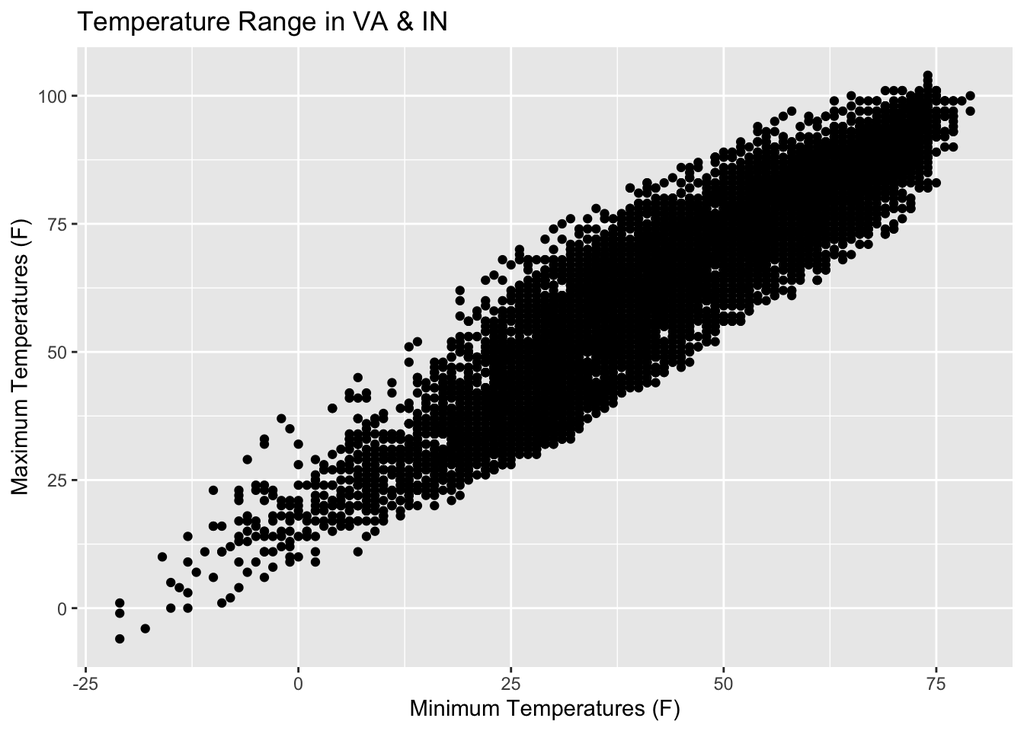

```r
# ggplot is the function - not ggplot2
# ggplots follow a distinct syntax or logic from R's
## base plotting package:
###  ggplot(data.frame,
###        aes(x= column,
###            y = column)) +
###     geometry()…

## A: Simple ggplot2 scatterplot
ggplot(weather, #tell R the dataframe
       aes(x = tmin, #then the x variable
           y = tmax))+ #then the y variable
  geom_point()+ #geometries explain the type of plot we want
  labs(x = "Minimum Temperatures (F)",
       y = "Maximum Temperatures (F)",
       title = "Temperature Range in VA & IN") #not main, main is for base R plot
```

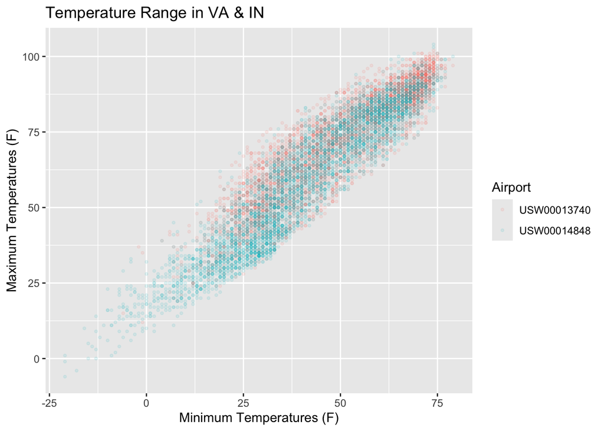

```r
## B: Complicated ggplot2 scatterplot
ggplot(weather,
       aes(x = tmin,
           y = tmax,
           color = station_id))+
  geom_point(alpha = 0.1, #alpha is the transparancy of the points
            size = 0.8)+
 labs(x = "Minimum Temperatures (F)",
       y = "Maximum Temperatures (F)",
       title = "Temperature Range in VA & IN",
      color = "Airport") #if you use color above, use color below
```

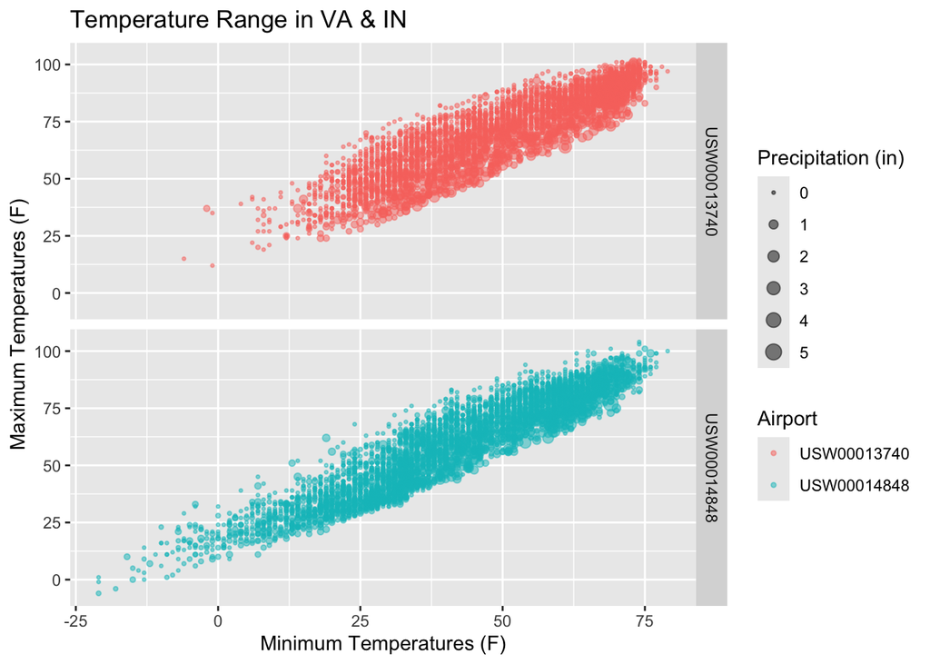

```r
## C: A simplified complicated plot that
### splits up the two station_ids into facets

ggplot(weather,
       aes(x = tmin,
           y = tmax,
           color = station_id))+
  geom_point(shape = 20, #shape is the shape of the points, can change
             alpha = 0.5, #alpha is the transparency of the points
             aes(size = prcp))+ #look up ggplot shapes; there
  facet_grid(row = vars(station_id))+ #col (column) instead of row are better to show to lows and highs better
  labs(x = "Minimum Temperatures (F)",
       y = "Maximum Temperatures (F)",
      title = "Temperature Range in VA & IN",
      color = "Airport",
      size = "Precipitation (in)") #labels the side tittles
```

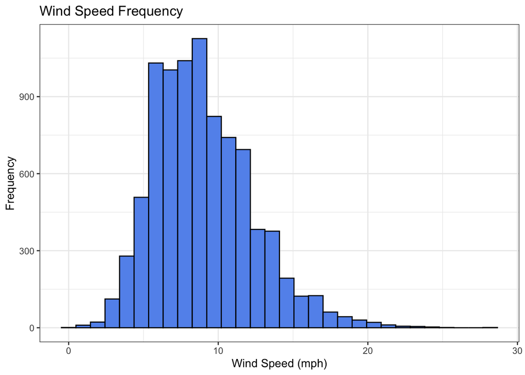

```r
## D: Pretty histogram of wind speeds
ggplot(weather,
       aes(x = wind_speed,))+
  geom_histogram(bins = 30,
                 fill = "cornflowerblue",#fill is for wide objects
                 color = "black")+#color is for narrow objects
  labs(x = "Wind Speed (mph)",
       y = "Frequency",
       title = "Wind Speed Frequency")+
  theme_bw()
```

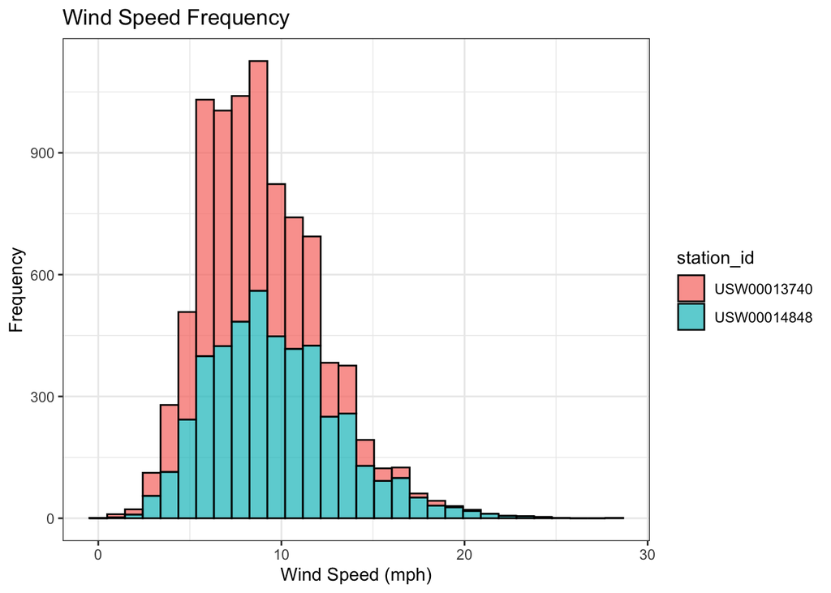

```r
ggplot(weather,
       aes(x = wind_speed,
           fill = station_id))+ #if using fill by a variable, it must go in the aesthetics
  geom_histogram(bins = 30,
                 color = "black",
                 alpha = 0.7)+#color is for narrow objects
  labs(x = "Wind Speed (mph)",
       y = "Frequency",
       title = "Wind Speed Frequency")+
  theme_bw()
```

We can even make some pretty cool graphs, in which we can look at the frequency of wind direction at our two different airports.

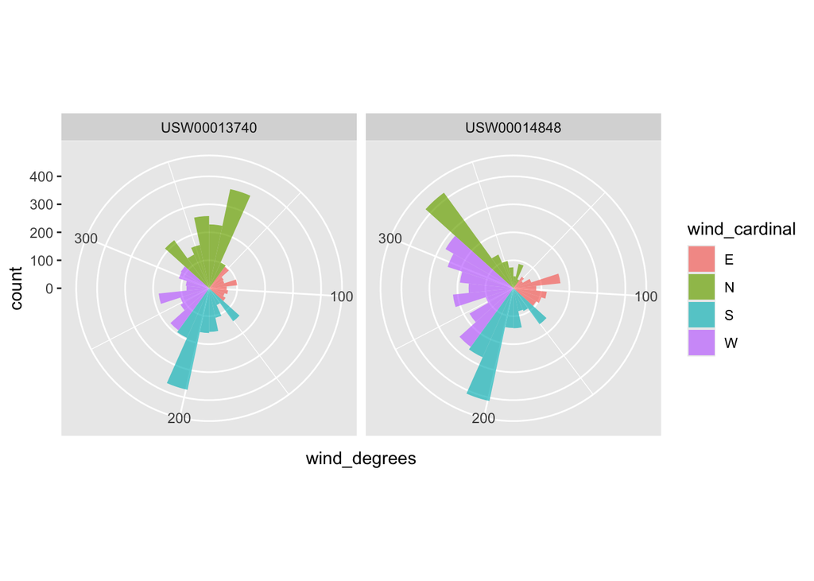

```r
ggplot(weather,
      aes(x = wind_degrees,
          fill = wind_cardinal))+
  geom_histogram(alpha = 0.7)+
  coord_polar()+
  facet_grid(cols = vars(station_id))
```